# Project Python Foundations: FoodHub Data Analysis

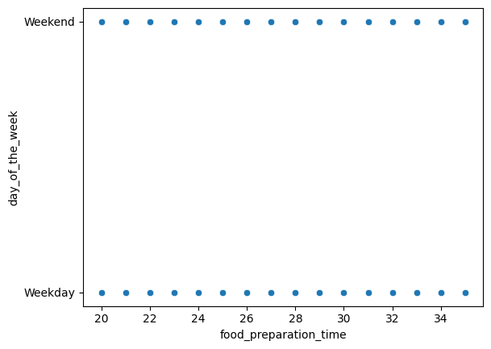

```python
# Scatter plot of food preparation time and cost_of_the_order
sns.scatterplot(data=df, x='food_preparation_time', y='day_of_the_week');
```

### Observations: Whether it was a weekday or a weekend, food preparation time was between 20 minutes and 35 minutes.

```python
#-----Point Plots-----
```

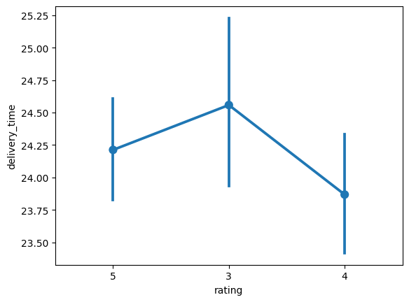

```python
# Point plot of rating and delivery time
sns.pointplot(data=df, x='rating', y='delivery_time');
```

### Observations: The range of delivery times for orders that received a rating of 3 was the widest range.

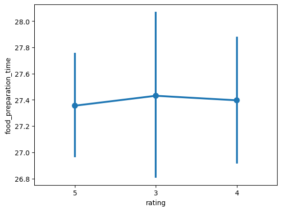

```python
# Point plot of rating and food_preparation_time
sns.pointplot(data=df, x='rating', y='food_preparation_time');
```

### Observations: The range of food preparation time for orders that received a rating of 3 was the widest range.

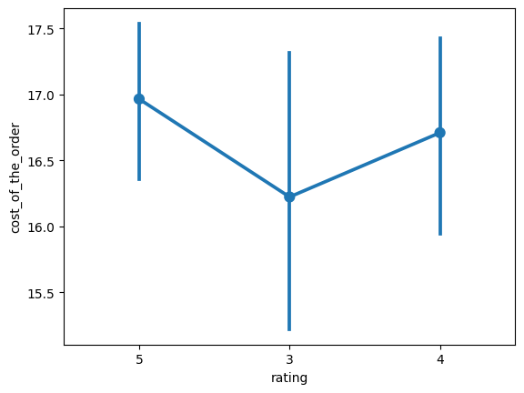

```python
# Point plot of rating and cost_of_the_order
sns.pointplot(data=df, x='rating', y='cost_of_the_order');
```

```python
# For Revenue Generated
df.groupby(['restaurant_name'])['cost_of_the_order'].sum().sort_values(ascending=False).head(14)
```

```
restaurant_name
Shake Shack                      3579.53
The Meatball Shop                2145.21
Blue Ribbon Sushi                1903.95
Blue Ribbon Fried Chicken        1662.29
Parm                             1112.76
RedFarm Broadway                  965.13
RedFarm Hudson                    921.21
TAO                               834.50
Han Dynasty                       755.29
Blue Ribbon Sushi Bar & Grill     666.62
Rubirosa                          660.45
Sushi of Gari 46                  640.87
Nobu Next Door                    623.67
Five Guys Burgers and Fries       506.47
Name: cost_of_the_order, dtype: float64
```

### Observations: Shake Shack generated 3,579.53 dollars (the most) in revenue. The Meatball Shop generated 2,145.21 (2nd) dollars in revenue. Blue Ribbon Sushi generated 1,903.95 dollars (3rd) in revenue.

### **Question 13:** The company wants to provide a promotional offer in the advertisement of the restaurants. The condition to get the offer is that the restaurants must have a rating count of more than 50 and the average rating should be greater than 4. Find the restaurants fulfilling the criteria to get the promotional offer. [3 marks]

```python
# View rating column
df['rating']
```

```
0       NaN
1       NaN
2         5
3         3
4         4
       ...
1893      5
1894      5
1895    NaN
1896      5
1897    NaN
Name: rating, Length: 1898, dtype: object
```

```python
# Filter rated restaurants
rated_restaurants = df[df['rating'] != 'Not Given'].copy()
rated_restaurants
```

|  | order_id | customer_id | restaurant_name | cuisine_type | cost_of_the_order | day_of_the_week | rating | food_preparation_time | delivery_time |
| --- | --- | --- | --- | --- | --- | --- | --- | --- | --- |
| 0 | 1477147 | 337525 | Hangawi | Korean | 30.75 | Weekend | NaN | 25 | 20 |
| 1 | 1477685 | 358141 | Blue Ribbon Sushi Izakaya | Japanese | 12.08 | Weekend | NaN | 25 | 23 |
| 2 | 1477070 | 66393 | Cafe Habana | Mexican | 12.23 | Weekday | 5 | 23 | 28 |
| 3 | 1477334 | 106968 | Blue Ribbon Fried Chicken | American | 29.20 | Weekend | 3 | 25 | 15 |
| 4 | 1478249 | 76942 | Dirty Bird to Go | American | 11.59 | Weekday | 4 | 25 | 24 |
| ... | ... | ... | ... | ... | ... | ... | ... | ... | ... |
| 1893 | 1476701 | 292602 | Chipotle Mexican Grill $1.99 Delivery | Mexican | 22.31 | Weekend | 5 | 31 | 17 |
| 1894 | 1477421 | 397537 | The Smile | American | 12.18 | Weekend | 5 | 31 | 19 |
| 1895 | 1477819 | 35309 | Blue Ribbon Sushi | Japanese | 25.22 | Weekday | NaN | 31 | 24 |
| 1896 | 1477513 | 64151 | Jack's Wife Freda | Mediterranean | 12.18 | Weekday | 5 | 23 | 31 |
| 1897 | 1478056 | 120353 | Blue Ribbon Sushi | Japanese | 19.45 | Weekend | NaN | 28 | 24 |

1898 rows × 9 columns

```python
# Convert rating datatype to integer
df['rating'] = df['rating'].astype("Int64")
df['rating']
```

```
0       <NA>
1       <NA>
2          5
3          3
4          4
        ...
1893       5
1894       5
1895    <NA>
1896       5
1897    <NA>
Name: rating, Length: 1898, dtype: Int64
```

```python
# Combine restaurant names and ratings count in a dataframe for promotional offer
promo_rated_restaurants = rated_restaurants.groupby(['restaurant_name'])['rating'].count().sort_values(ascending=False).reset_index()
promo_rated_restaurants.head()
```

|  | restaurant_name | rating |
| --- | --- | --- |
| 0 | Shake Shack | 133 |
| 1 | The Meatball Shop | 84 |
| 2 | Blue Ribbon Sushi | 73 |
| 3 | Blue Ribbon Fried Chicken | 64 |
| 4 | RedFarm Broadway | 41 |

```python
# Restaurants with above fifty rating count
above_fifty_ratings = promo_rated_restaurants[promo_rated_restaurants['rating']>50]['restaurant_name']
above_fifty_ratings
```

```
0                  Shake Shack
1            The Meatball Shop
2            Blue Ribbon Sushi
3    Blue Ribbon Fried Chicken
Name: restaurant_name, dtype: object
```

```python
# To retrieve data of restaurants above fifty rating count
rated_restaurants_names = rated_restaurants[rated_restaurants['restaurant_name'].isin(above_fifty_ratings)].copy()
rated_restaurants_names
```

|  | order_id | customer_id | restaurant_name | cuisine_type | cost_of_the_order | day_of_the_week | rating | food_preparation_time | delivery_time |
| --- | --- | --- | --- | --- | --- | --- | --- | --- | --- |
| 3 | 1477334 | 106968 | Blue Ribbon Fried Chicken | American | 29.20 | Weekend | 3 | 25 | 15 |
| 6 | 1477894 | 157711 | The Meatball Shop | Italian | 6.07 | Weekend | NaN | 28 | 21 |
| 12 | 1476966 | 129969 | Blue Ribbon Fried Chicken | American | 24.30 | Weekend | 5 | 23 | 17 |
| 15 | 1477414 | 66222 | Shake Shack | American | 16.20 | Weekend | 5 | 33 | 25 |
| 19 | 1477354 | 67487 | Blue Ribbon Sushi | Japanese | 16.20 | Weekend | 4 | 35 | 26 |
| ... | ... | ... | ... | ... | ... | ... | ... | ... | ... |
| 1887 | 1476873 | 237616 | Shake Shack | American | 5.82 | Weekend | NaN | 26 | 30 |
| 1888 | 1477353 | 106324 | The Meatball Shop | Italian | 16.20 | Weekend | 5 | 21 | 26 |
| 1891 | 1476981 | 138586 | Shake Shack | American | 5.82 | Weekend | NaN | 22 | 28 |
| 1895 | 1477819 | 35309 | Blue Ribbon Sushi | Japanese | 25.22 | Weekday | NaN | 31 | 24 |
| 1897 | 1478056 | 120353 | Blue Ribbon Sushi | Japanese | 19.45 | Weekend | NaN | 28 | 24 |

566 rows × 9 columns

```python
rated_restaurants_names.groupby(['restaurant_name'])['rating'].mean().sort_values(ascending=False).reset_index().dropna()
```

[output not shown]

[output cut: 105 more lines]

[output not shown]

### **Question 14:** The company charges the restaurant 25% on the orders having cost greater than 20 dollars and 15% on the orders having cost greater than 5 dollars. Find the net revenue generated by the company across all orders. [3 marks]

```python
# To view net revenue
def net_revenue(i):
  if i > 20:
    return i*.25
  elif i > 5:
    return i*.15
  else:
    return i*0

df['Net_Revenue'] = df['cost_of_the_order'].apply(net_revenue)
df.head()
```

|  | order_id | customer_id | restaurant_name | cuisine_type | cost_of_the_order | day_of_the_week | rating | food_preparation_time | delivery_time | Net_Revenue |
| --- | --- | --- | --- | --- | --- | --- | --- | --- | --- | --- |
| 0 | 1477147 | 337525 | Hangawi | Korean | 30.75 | Weekend | <NA> | 25 | 20 | 7.6875 |
| 1 | 1477685 | 358141 | Blue Ribbon Sushi Izakaya | Japanese | 12.08 | Weekend | <NA> | 25 | 23 | 1.8120 |
| 2 | 1477070 | 66393 | Cafe Habana | Mexican | 12.23 | Weekday | 5 | 23 | 28 | 1.8345 |
| 3 | 1477334 | 106968 | Blue Ribbon Fried Chicken | American | 29.20 | Weekend | 3 | 25 | 15 | 7.3000 |
| 4 | 1478249 | 76942 | Dirty Bird to Go | American | 11.59 | Weekday | 4 | 25 | 24 | 1.7385 |

```python
#For Total Net Revenue
total_net_revenue = df['Net_Revenue'].sum()
print('Total Net Revenue: $' + str(total_net_revenue))
```

```
Total Net Revenue: $6166.303
```

#### Observations: Total Net Revenue for the orders places was 6,166.30 dollars.

### **Question 15:** The company wants to analyze the total time required to deliver the food. What percentage of orders take more than 60 minutes to get delivered from the time the order is placed? (The food has to be prepared and then delivered.) [2 marks]

```python
# Unique Food Preparation Times
df['food_preparation_time'].unique()
```

```
array([25, 23, 20, 28, 33, 21, 29, 34, 24, 30, 35, 32, 31, 27, 22, 26])
```

```python
# Unique Delivery Times
df['delivery_time'].unique()
```

```
array([20, 23, 28, 15, 24, 21, 30, 26, 22, 17, 25, 16, 29, 27, 18, 31, 32,
       19, 33])
```

```python
# Statistical Summary of Delivery Times
df['delivery_time'].describe().T
```

```
count    1898.000000
mean       24.161749
std         4.972637
min        15.000000
25%        20.000000
50%        25.000000
75%        28.000000
max        33.000000
Name: delivery_time, dtype: float64
```

```python
# Statistical Summary of Food Preparation Times
df['food_preparation_time'].describe().T
```

```
count    1898.000000
mean       27.371970
std         4.632481
min        20.000000
25%        23.000000
50%        27.000000
75%        31.000000
max        35.000000
Name: food_preparation_time, dtype: float64
```

```python
# Total Time to deliver
df['total_time'] = df['food_preparation_time'] + df['delivery_time']
df['total_time']
```

```
0       45
1       48
2       51
3       40
4       49
        ..
1893    48
1894    50
1895    55
1896    54
1897    52
Name: total_time, Length: 1898, dtype: int64
```

```python
# Total Time to deliver above 60 minutes
time_above_sixty = df[df['total_time']>60]
time_above_sixty
```

|  | order_id | customer_id | restaurant_name | cuisine_type | cost_of_the_order | day_of_the_week | rating | food_preparation_time | delivery_time | Net_Revenue | total_time |
| --- | --- | --- | --- | --- | --- | --- | --- | --- | --- | --- | --- |
| 7 | 1477859 | 89574 | Barbounia | Mediterranean | 5.97 | Weekday | 3 | 33 | 30 | 0.8955 | 63 |
| 10 | 1477895 | 143926 | Big Wong Restaurant _¤¾Ñ¼ | Chinese | 5.92 | Weekday | <NA> | 34 | 28 | 0.8880 | 62 |
| 19 | 1477354 | 67487 | Blue Ribbon Sushi | Japanese | 16.20 | Weekend | 4 | 35 | 26 | 2.4300 | 61 |
| 24 | 1476714 | 363783 | Cafe Mogador | Middle Eastern | 15.86 | Weekday | <NA> | 32 | 29 | 2.3790 | 61 |
| 54 | 1477760 | 130507 | Jack's Wife Freda | Mediterranean | 22.75 | Weekend | 3 | 35 | 29 | 5.6875 | 64 |
| ... | ... | ... | ... | ... | ... | ... | ... | ... | ... | ... | ... |
| 1869 | 1476923 | 50199 | J. G. Melon | American | 19.40 | Weekday | 4 | 35 | 26 | 2.9100 | 61 |
| 1873 | 1478148 | 261371 | Shake Shack | American | 22.31 | Weekend | <NA> | 35 | 28 | 5.5775 | 63 |
| 1875 | 1478039 | 292343 | Amy Ruth's | Southern | 12.23 | Weekday | <NA> | 32 | 33 | 1.8345 | 65 |
| 1880 | 1477466 | 222734 | Shake Shack | American | 13.97 | Weekend | 5 | 35 | 27 | 2.0955 | 62 |
| 1889 | 1478190 | 94152 | RedFarm Broadway | Chinese | 8.68 | Weekday | 3 | 33 | 30 | 1.3020 | 63 |

200 rows × 11 columns

```python
# Percentage of orders with a Total Time to deliver above 60 minutes
time_above_sixty_percentage = (time_above_sixty.shape[0]/ df.shape[0])*100
time_above_sixty_percentage
```

```
10.537407797681771
```

#### Observations: 10.54 percent of orders took longer than 60 minutes to complete.

### **Question 16:** The company wants to analyze the delivery time of the orders on weekdays and weekends. How does the mean delivery time vary during weekdays and weekends? [2 marks]

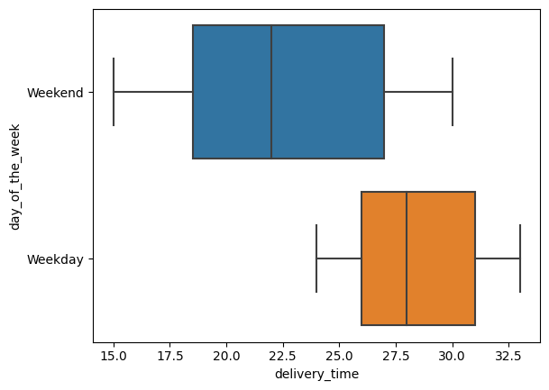

```python
# Box plot for delivery time and day of the week
sns.boxplot(data=df, x='delivery_time', y='day_of_the_week');
```

```python
# For average delivery time for day of the week
avg_delivery_time = df.groupby(['day_of_the_week']).mean()[['delivery_time']]
avg_delivery_time
```

| day_of_the_week | delivery_time |
| --- | --- |
| Weekday | 28.340037 |
| Weekend | 22.470022 |

### Observations: It takes almost 6 minutes less to deliver on the weekend than on weekdays, on average.

### Conclusion and Recommendations

### **Question 17:** What are your conclusions from the analysis? What recommendations would you like to share to help improve the business? (You can use cuisine type and feedback ratings to drive your business recommendations.) [6 marks]

### Conclusions:

- Food delivery time is faster on the weekend.
- There were more orders placed on the weekend.
- Cost didn't show a significant impact towards rating.
- Total time to receive order had little impact on the rating.
- American food was most popular.

### Recommendations:

- Food Hub should explore Shake Shack and the Meaball Shop's methods for providing customer service.
- Shake Shack has the highest number of ratings. Food Hub should explore Shake Shack's customer base to determine why the customer was willing to respond more often to rating Shake Shack as opposed to any other restaurant.
- Food Hub should incentivize the most popular restaurants to provide feedback on customer service practices, specific order details to determine what meals are specifically receiving each rating at each restaurant, and information regarding the impact on the taste of the food at the restaurant to determine if taste is weighted heavier when determining ratings.
- With the above recommendations, Food Hub will have more insight into promoting higher ratings.